# test CellScore With SelectedHsapienData normalized with Deseq2 normalization

Siyuan

6/29/2020

### Data preprocessing

#### creating a map between cell types and their abbreviations

```r
getCellTypeMap <- function() {
    ## Hardcode abbreviations for each cell type
    cellTypes <- c(
        "RPE",
        "ESC",
        "ESC.d",
        "ESC.t",
        "iPS",  ## check the comment
        "IPS",
        "URI",
        "PBMC",
        "HUVEC",

        "derived cardiomyocyte",
        "hepatocyte-like cell",
        "hepatocyte",
        "fetal liver",
        "derived dopaminergic neuron",
        "derived neuron",
        "spinal cord",
        "derived neural progenitor cell",
        "derived RPE",
        "fetal RPE",
        "fetal heart",
        "derived neural stem cell",
        "naive IPS",
        "naive ESC",
        "fetal brain",
        "derived pancreatic b-like cell",
        "derived endoderm",
        "derived foregut endoderm",
        "derived hepatic endoderm",
        "derived early hepatocyte",
        "derived late hepatocyte",
        "fibroblast",
        "induced neuron",
        "fibroblast.treated",
        "cardiomyocytes",
        "hepatocytes",
        "dopaminergic neurons",
        "neurons",
        "neual progenitor cell",
        "neural stem cells",
        "pancreatic beta cell",
        "endoderm",
        "foregut endoderm",
        "hepatic endoderm",
        "neuron",
        "lymphocyte")

    abbrv <- c(
        ## Original abbreviations
        "RPE",
        "ESC",
        "ESC.d",
        "ESC.t",
        "IPS",
        "IPS",
        "URI",
        "PBMC",
        "HUVEC",
        ## Abbreviations named by me
        "dCDM",
        "HPTL",
        "HPT",
        "fLIV",
        "dDPNEU",
        "dNEU",
        "SPC",
        "dNEUPR",
        "dRPE",
        "fRPE",
        "fHRT",
        "dNEUST",
        "nIPS",
        "nESC",
        "fBRN",
        "dPCB",
        "dEDD",
        "dFEDD",
        "dHPTEDD",
        "dEHPT",
        "dLHPT",
        "FIB",
        "INEU",
        "FIB.t",
        "CDM",
        "HPT",
        "DPNEU",
        "NEU",
        "NEUPR",
        "NEUST",
        "PCB",
        "EDD",
        "FEDD",
        "HPTEDD",
        "NEU",
        "LPC")

    cellTypeMap <- setNames(abbrv, cellTypes)

    # Mapping from full cell type names to their abbrvs
    print(cellTypeMap)
    cellTypeMap
}
```

#### Prepare ‘cell.change’ data frame

The following code prepares ‘cell.change’ data frame. This data frame contains 3 columns, which are ‘start’, ‘test’ and ‘target’. Each row in the data frame represents the transition in an experiment. The values in the ‘start’ column are the abbreviations of parental cell types (or starting cell types) in the transitions. The values in ‘target’ column are the abbreviations of the target cell types in the transitions. The values in ‘test’ column are in the format ‘{test_cell_type}-{start}’, where ‘{test_cell_type}’ are the abbreviations of the name assigned to the test cells and ‘{start}’ are the abbreviations of parental cell types (or starting cell types). The following function ‘prepareSampleTransitions’ is used to generate and save the ‘cell.change’ in a tsv file and is not part of ‘CellScore’ library. The user should create this data frame based on the experiment data.

```r
prepareSampleTransitions <- function() {

    dat <- read.csv(system.file("extdata",
                                  "sampleMetadata.csv",
                                  package = "CellScore"),
                    header = TRUE)

    uniqueCellTypes <- unique(c(as.array(dat$general_cell_type),
                                as.array(dat$target_cell_type),
                                as.array(dat$parental_cell_type)))

    # Show all the unique cell types in the data
    print(uniqueCellTypes)

    cellTypeMap <- getCellTypeMap()

    uniqueTransitions <- unique(dat[dat$category == 'test',
                                    c('parental_cell_type',
                                      'general_cell_type',
                                      'target_cell_type')])

    colnames(uniqueTransitions) <- c("start",   "test", "target")

    ## Exclude samples without parental cell types or without target cell type
    uniqueTransitions <- uniqueTransitions[!is.na(uniqueTransitions$start) &
                                             !is.na(uniqueTransitions$target) &
                                             uniqueTransitions$start != '' &
                                             uniqueTransitions$target != '', ]

    ## Replace full cell type names with abbreviations
    uniqueTransitionsAbbrv <- as.data.frame(lapply(uniqueTransitions,
                                                   function(element) {
                                                      (cellTypeMap[element])
                                                   }))


    ## Format 'test' column
    uniqueTransitionsAbbrv$test <- paste(uniqueTransitionsAbbrv$test,
                                         uniqueTransitionsAbbrv$start,
                                         sep = '-')

    tempDirPath <- paste(getwd(), 'temp', sep = '/')
    dir.create(tempDirPath)

    write.table(uniqueTransitionsAbbrv,
                file = system.file("extdata", "exampleTransitionsHsapienData.tsv",
                                   package="CellScore"),
                quote = FALSE,
                sep = '\t')

    uniqueTransitionsAbbrv
}
```

### Calculate ‘CellScore’

#### Generate ‘OnOff’ score by run ‘OnOff’ function with ‘cell.change’ data frame and experiment data.

‘CellScore’ library analyze the ‘CellScore’ of test cells with given standard cells in the experiment data. The ‘category’ of test cells and standard cells are ‘test’ and ‘standard’ respectively. Transitions with insufficient standard cell types (at least 3 for both ‘start’ and ‘target’) would be ignored by ‘CellScore’ library.

```r
library(SummarizedExperiment)
library(CellScore)
library(DEE2HsapienData)

prepareSampleTransitions()
```

```
##  [1] "RPE"                            "ESC"
##  [3] "ESC.d"                          "derived cardiomyocyte"
##  [5] "ESC.t"                          "hepatocyte-like cell"
##  [7] "hepatocyte"                     "fetal liver"
##  [9] "derived dopaminergic neuron"    "derived neuron"
## [11] "spinal cord"                    "derived neural progenitor cell"
## [13] "derived RPE"                    "fetal RPE"
## [15] "iPS"                            "fetal heart"
## [17] "derived neural stem cell"       "IPS"
## [19] "naive IPS"                      "naive ESC"
## [21] "fetal brain"                    "derived pancreatic b-like cell"
## [23] "derived endoderm"               "derived foregut endoderm"
## [25] "derived hepatic endoderm"       "derived early hepatocyte"
## [27] "derived late hepatocyte"        "fibroblast"
## [29] "induced neuron"                 "fibroblast.treated"
## [31] NA                               "cardiomyocytes"
## [33] "hepatocytes"                    "dopaminergic neurons"
## [35] "neurons"                        "neual progenitor cell"
## [37] "neural stem cells"              "pancreatic beta cell"
## [39] "endoderm"                       "foregut endoderm"
## [41] "hepatic endoderm"               "neuron"
## [43] ""                               "lymphocyte"
## [45] "URI"                            "PBMC"
## [47] "HUVEC"
##                            RPE                            ESC
##                          "RPE"                          "ESC"
##                          ESC.d                          ESC.t
##                        "ESC.d"                        "ESC.t"
##                            iPS                            IPS
##                          "IPS"                          "IPS"
##                            URI                           PBMC
##                          "URI"                         "PBMC"
##                          HUVEC          derived cardiomyocyte
##                        "HUVEC"                         "dCDM"
##           hepatocyte-like cell                     hepatocyte
##                         "HPTL"                          "HPT"
##                    fetal liver    derived dopaminergic neuron
##                         "fLIV"                       "dDPNEU"
##                 derived neuron                    spinal cord
##                         "dNEU"                          "SPC"
```

[output cut: 15 more lines]

```
##                          "FIB"                         "INEU"
##             fibroblast.treated                 cardiomyocytes
##                        "FIB.t"                          "CDM"
##                    hepatocytes           dopaminergic neurons
##                          "HPT"                        "DPNEU"
##                        neurons          neual progenitor cell
##                          "NEU"                        "NEUPR"
##              neural stem cells           pancreatic beta cell
##                        "NEUST"                          "PCB"
##                       endoderm               foregut endoderm
##                          "EDD"                         "FEDD"
##               hepatic endoderm                         neuron
##                       "HPTEDD"                          "NEU"
##                     lymphocyte
##                          "LPC"
```

```
##    start        test target
## 1    ESC    dCDM-ESC    CDM
## 2    ESC    HPTL-ESC    HPT
## 3    ESC  dDPNEU-ESC  DPNEU
## 4    IPS    dNEU-IPS    NEU
## 5    ESC    dNEU-ESC    NEU
## 6    ESC  dNEUPR-ESC  NEUPR
## 7    ESC    dRPE-ESC    RPE
## 8    IPS    dRPE-IPS    RPE
## 9    IPS    dCDM-IPS    CDM
## 10   IPS  dNEUST-IPS  NEUST
## 11   IPS    dPCB-IPS    PCB
## 12   ESC    dEDD-ESC    EDD
## 13   ESC   dFEDD-ESC   FEDD
## 14   ESC dHPTEDD-ESC HPTEDD
## 15   ESC   dEHPT-ESC    HPT
## 16   ESC   dLHPT-ESC    HPT
## 17   IPS    dEDD-IPS    EDD
## 18   IPS   dFEDD-IPS   FEDD
## 19   IPS dHPTEDD-IPS HPTEDD
## 20   IPS   dEHPT-IPS    HPT
## 21   IPS   dLHPT-IPS    HPT
## 22   FIB    INEU-FIB    NEU
```

```r
CellTypeMap <- getCellTypeMap()
```

```
##                            RPE                            ESC
##                          "RPE"                          "ESC"
##                          ESC.d                          ESC.t
##                        "ESC.d"                        "ESC.t"
##                            iPS                            IPS
##                          "IPS"                          "IPS"
##                            URI                           PBMC
##                          "URI"                         "PBMC"
##                          HUVEC          derived cardiomyocyte
##                        "HUVEC"                         "dCDM"
##           hepatocyte-like cell                     hepatocyte
##                         "HPTL"                          "HPT"
##                    fetal liver    derived dopaminergic neuron
##                         "fLIV"                       "dDPNEU"
##                 derived neuron                    spinal cord
##                         "dNEU"                          "SPC"
## derived neural progenitor cell                    derived RPE
##                       "dNEUPR"                         "dRPE"
##                      fetal RPE                    fetal heart
##                         "fRPE"                         "fHRT"
##       derived neural stem cell                      naive IPS
##                       "dNEUST"                         "nIPS"
##                      naive ESC                    fetal brain
##                         "nESC"                         "fBRN"
## derived pancreatic b-like cell               derived endoderm
##                         "dPCB"                         "dEDD"
##       derived foregut endoderm       derived hepatic endoderm
##                        "dFEDD"                      "dHPTEDD"
##       derived early hepatocyte        derived late hepatocyte
##                        "dEHPT"                        "dLHPT"
##                     fibroblast                 induced neuron
##                          "FIB"                         "INEU"
##             fibroblast.treated                 cardiomyocytes
##                        "FIB.t"                          "CDM"
##                    hepatocytes           dopaminergic neurons
##                          "HPT"                        "DPNEU"
##                        neurons          neual progenitor cell
##                          "NEU"                        "NEUPR"
##              neural stem cells           pancreatic beta cell
##                        "NEUST"                          "PCB"
##                       endoderm               foregut endoderm
##                          "EDD"                         "FEDD"
##               hepatic endoderm                         neuron
##                       "HPTEDD"                          "NEU"
##                     lymphocyte
##                          "LPC"
```

```r
rdata.path <- system.file("extdata", "deseq2NormalizedDee2Data",
  package="CellScore")
tsvdata.path <- system.file("extdata", "exampleTransitionsHsapienData.tsv",
  package="CellScore")


if (file.exists(rdata.path) && file.exists(tsvdata.path)) {
  deseq2NormalizedDee2Data <- readRDS(rdata.path)
  normalizedSExpr <- deseq2NormalizedDee2Data$normalizedSExpr

  # replace values in 'general_cell_type' with abbrvs
  colData(normalizedSExpr)[, 'general_cell_type'] <- unname(as.array(sapply(
    normalizedSExpr$general_cell_type,
    function(element) CellTypeMap[[element]], USE.NAMES = FALSE)))

  # replace values in 'parental_cell_type' with abbrvs
  colData(normalizedSExpr)[, 'parental_cell_type'] <- unname(as.array(sapply(
    normalizedSExpr$parental_cell_type,
    function(element) {
      if (is.na(element)) {
        return(NA)
      }
      CellTypeMap[[element]]
    }, USE.NAMES = FALSE)))

  # set values of 'sub_cell_type1' column
  colData(normalizedSExpr)$sub_cell_type1 <- paste(
    colData(normalizedSExpr)$general_cell_type,
    colData(normalizedSExpr)$parental_cell_type,
    sep = '-')

  pcaPlot(normalizedSExpr)


  cell.change <- read.delim(
    file=tsvdata.path,
    sep="\t",
    header=TRUE,
    stringsAsFactors=FALSE)

  print("Content of cell.change")
  print(cell.change)

  print("'normalizedSExpr' returns")
  print(normalizedSExpr)
}
```

```
## [1] "Content of cell.change"
##    start        test target
## 1    ESC    dCDM-ESC    CDM
## 2    ESC    HPTL-ESC    HPT
## 3    ESC  dDPNEU-ESC  DPNEU
## 4    IPS    dNEU-IPS    NEU
## 5    ESC    dNEU-ESC    NEU
## 6    ESC  dNEUPR-ESC  NEUPR
## 7    ESC    dRPE-ESC    RPE
## 8    IPS    dRPE-IPS    RPE
## 9    IPS    dCDM-IPS    CDM
## 10   IPS  dNEUST-IPS  NEUST
## 11   IPS    dPCB-IPS    PCB
## 12   ESC    dEDD-ESC    EDD
## 13   ESC   dFEDD-ESC   FEDD
```

[output cut: 19 more lines]

Calculate ‘OnOff’ scores

```r
group.OnOff <- OnOff(normalizedSExpr, cell.change, out.put="marker.list")
print(summary(group.OnOff))
```

```
##         Length Class      Mode
## scores  10     data.frame list
## markers  8     data.frame list
```

```r
individ.OnOff <- OnOff(normalizedSExpr, cell.change, out.put="individual")
```

```
## To process 4 cell transitions
```

```
## Now processing transition ESC -> HPT
```

```
## Now processing transition ESC -> RPE
```

```
## Now processing transition IPS -> RPE
```

```
## Now processing transition IPS -> HPT
```

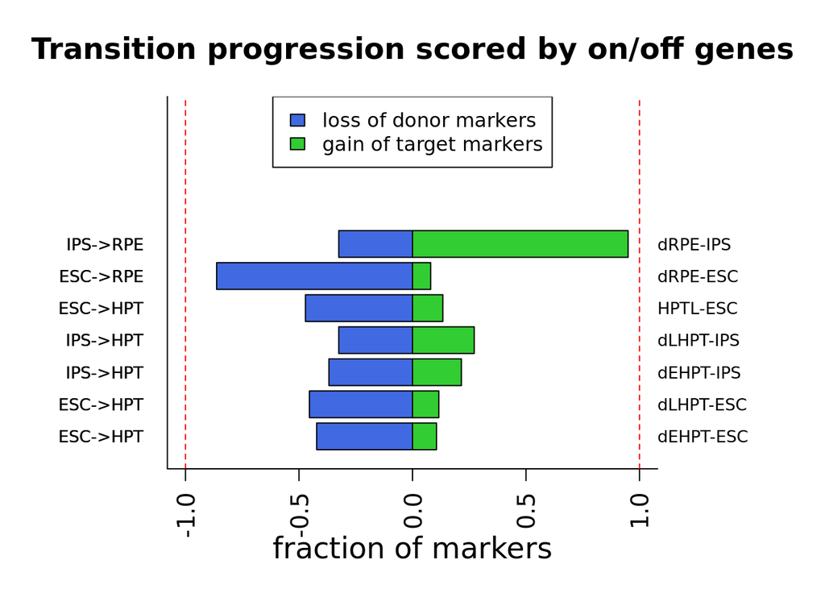

```r
barplot.out <- BarplotOnOff(normalizedSExpr, group.OnOff$scores)
```

```r
barplot.out
```

```
## $GroupComparisonsForPlot
##    start target      test markers.start markers.target start.mkrs.in.test
## 15   ESC    HPT dEHPT-ESC           566            785                327
## 16   ESC    HPT dLHPT-ESC           566            785                309
## 20   IPS    HPT dEHPT-IPS           763            548                482
## 21   IPS    HPT dLHPT-IPS           763            548                515
## 2    ESC    HPT  HPTL-ESC           566            785                299
## 7    ESC    RPE  dRPE-ESC           445             50                 61
## 8    IPS    RPE  dRPE-IPS           717             20                484
##    target.mkrs.in.test loss.start.mkrs gain.target.mkrs OnOffScore
## 15                  83       0.4222615        0.1057325  0.5279940
## 16                  91       0.4540636        0.1159236  0.5699872
## 20                 118       0.3682831        0.2153285  0.5836116
## 21                 149       0.3250328        0.2718978  0.5969306
## 2                  105       0.4717314        0.1337580  0.6054894
```

[output cut: 19 more lines]

```r
tmp.time <- system.time(cs <- CosineSimScore(normalizedSExpr, cell.change,
                                             iqr.cutoff=0.1))
```

```r
PlotCosineSimHeatmap(cs$cosine.general.groups, "general groups",
                     width=20, height=20, x=-20, y=3)
```

[output not shown]

```r
cellscore <- CellScore(normalizedSExpr, cell.change, individ.OnOff$scores,
                       cs$cosine.samples)
```

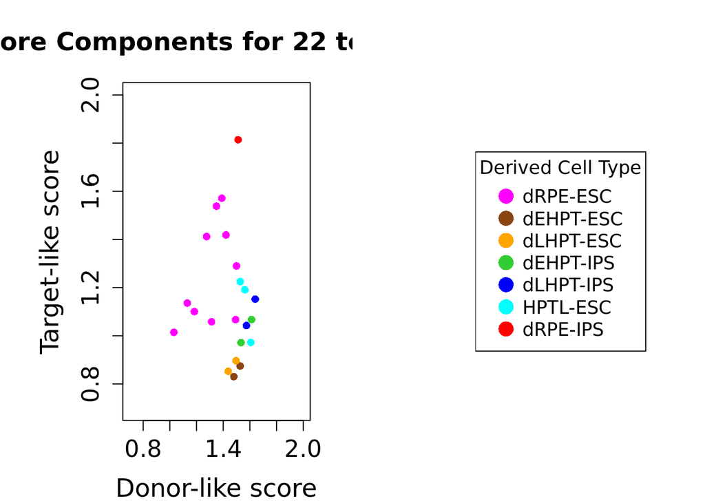

```r
ScatterplotCellScoreComponents(cellscore, cell.change, FALSE)
```